# Project1_Reproducible Research

AC

2/14/2021

Read the activivy dataset into data, and load the libraries: dplyr and lubricate

## Part I

```r
result <- data %>% group_by(date) %>% summarise(totalS = sum(steps, na.rm = TRUE), .groups = 'drop')
```

histogram of the total number of steps taken each day

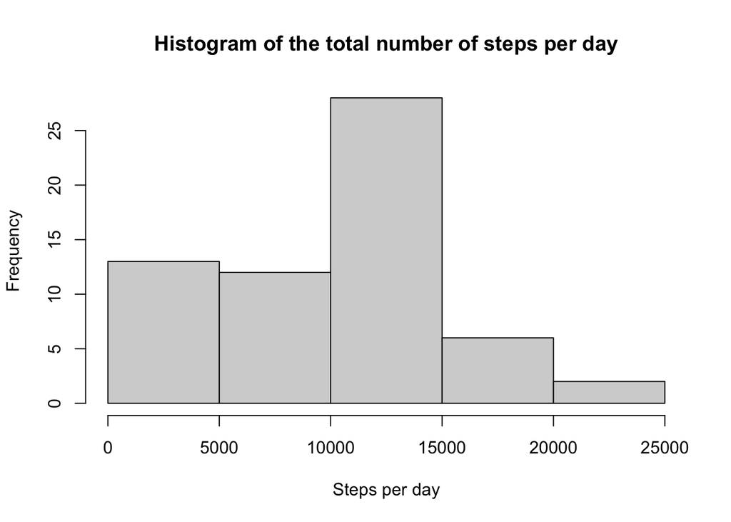

```r
hist(result$totalS, main = "Histogram of the total number of steps per day", xlab = "Steps per day")
```

```r
dev.copy(png,"Hist1.png")
```

```r
dev.off()
```

The mean of total steps taken per day is:

```r
TotalSteps_mean <- round(mean(result$totalS))
TotalSteps_mean
```

```
## [1] 9354
```

The median of total steps taken per day is:

```r
TotalSteps_median <- median(result$totalS)
TotalSteps_median
```

```
## [1] 10395
```

## Part II

Plotting the average daily activity per interval

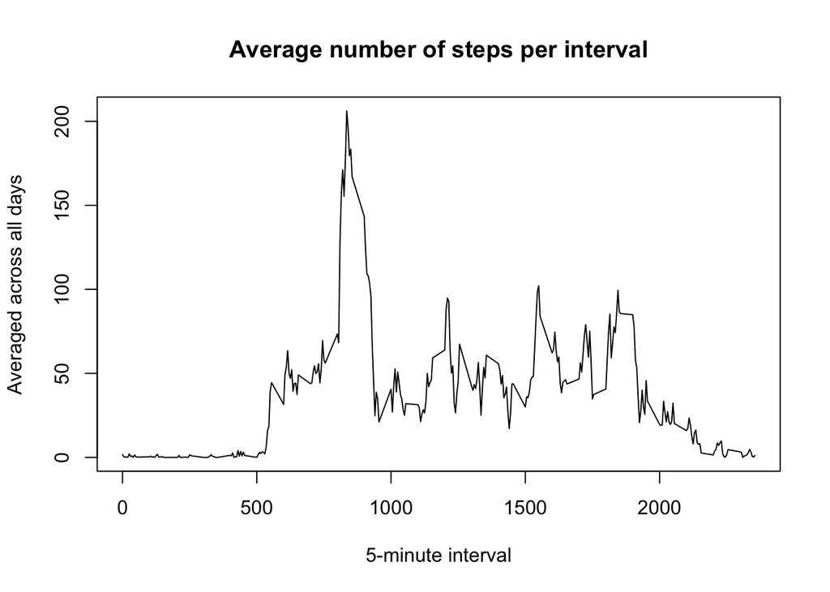

```r
average_per_interval <- aggregate(steps~interval, data, mean)
plot(average_per_interval$interval, average_per_interval$steps,  type = "l", main = "Average number of steps per interval", xlab = "5-minute interval", ylab = "Averaged across all days")
```

```r
dev.copy(png,"TimeSeriesAverageSteps.png")
```

```r
dev.off()
```

5-minute interval, on average across all the days in the dataset, that contains the maximum number of steps:

```r
maxActInterval <- average_per_interval[which.max(average_per_interval$steps), ]$interval
maxActInterval
```

```
## [1] 835
```

## Part III

Imputing missing values

Calculation the number of missing values in the data (activity.csv)

```r
missingvalues <- sum(is.na(data))
missingvalues
```

```
## [1] 2304
```

Filling the missing values

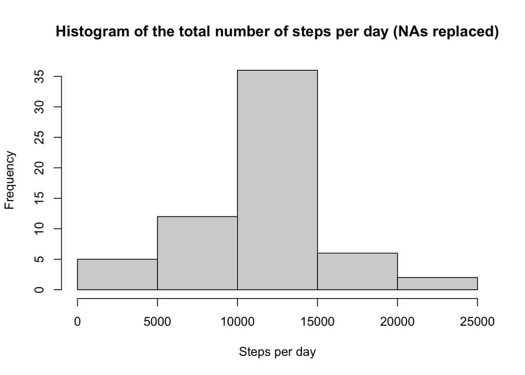

```r
#copy the original "data" to "data2"
data2 <- data

#alter data2 by replacing all the NA with the mean for that 5-minute interval
for (i in 1:nrow(data2)) {
    if(is.na(data2$steps[i])) {
        replace <- average_per_interval$steps[which(average_per_interval$interval == data2$interval[i])]
        data2$steps[i] <- replace
    }
}
#data2 is the same as data but NA's have been replaced with the 5min interval mean

# Aggregate the steps per day after replacing NA's
result2 <- data2 %>% group_by(date) %>% summarise(totalS = sum(steps, na.rm = TRUE), .groups = 'drop')

#Histogram of total of steps per day with NA's replaced
hist(result2$totalS, main = "Histogram of the total number of steps per day (NAs replaced)", xlab = "Steps per day")
```

```r
dev.copy(png,"Hist2.png")
```

```r
dev.off()
```

The mean of total steps taken per day is:

```r
TotalSteps_mean2 <- round(mean(result2$totalS))
TotalSteps_mean2
```

```
## [1] 10766
```

The median of total steps taken per day is:

```r
TotalSteps_median2 <- median(result2$totalS)
TotalSteps_median2
```

```
## [1] 10766.19
```

Evaluating if replacing the NA’s has an effect on the calculated mean and median of steps per day

```r
mean_the_same <- TotalSteps_mean2 == TotalSteps_mean
mean_the_same
```

```
## [1] FALSE
```

```r
median_the_same <-TotalSteps_median2 == TotalSteps_median
median_the_same
```

```
## [1] FALSE
```

Both the mean and the median change if the NA’s are replaced by the 5min interval average

## Part IV

Are there differences in activity patterns between weekdays and weekends? Use data2 (NA filled)

```r
data2$weekday <- weekdays(data2$date)
wday <- data2$weekday
for (i in 1:nrow(data2)) {
    if (wday[i] == "Saturday" || wday[i] == "Sunday") {
      wday[i] <- "weekend"
    } else {
      wday[i] <- "weekday"
    }
  }

# Add wday as a column of the data2 dataset
data2$wday <- wday

#load the lattice library
library(lattice)

#calculate the average of steps
average_per_interval2 <- data2 %>%
    group_by(wday, interval) %>%
    summarize(avg = mean(steps))
```

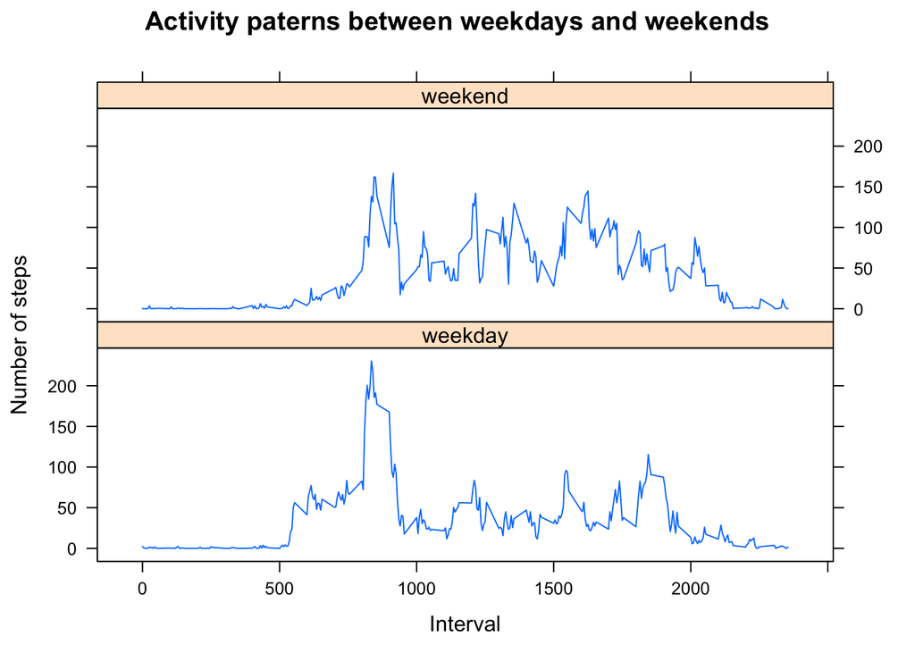

```r
#plot illustrating the diferent activity patterns between weekend and weekdays
xyplot(avg ~ interval | wday, average_per_interval2, type = "l", pch = 20, layout = c(1,2), main = "Activity paterns between weekdays and weekends", ylab = "Number of steps", xlab = "Interval")
```

```r
dev.copy(png,"ActivityWeekdaysWeekends.png")
```

```r
dev.off()
```